# Using Machine Learning For Facial Emotion Recognition

# EDA CONTINUED

## Random Sampling

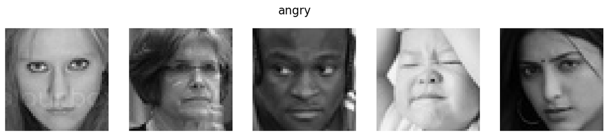

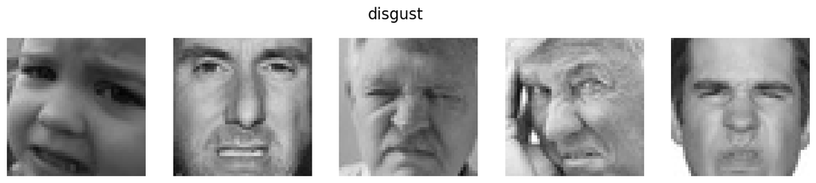

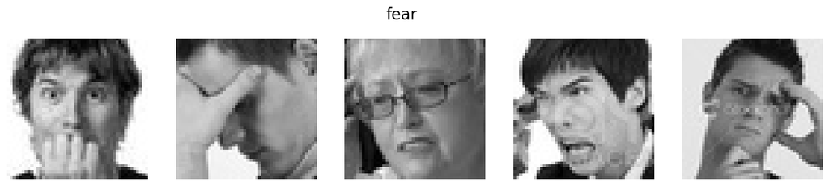

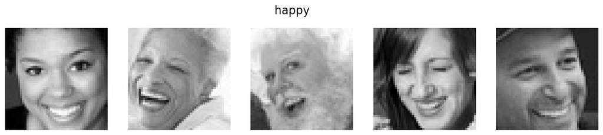

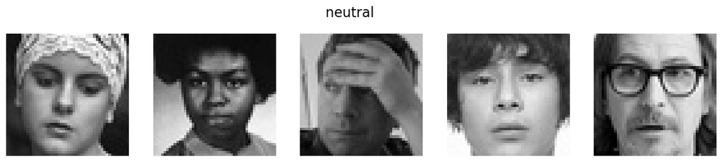

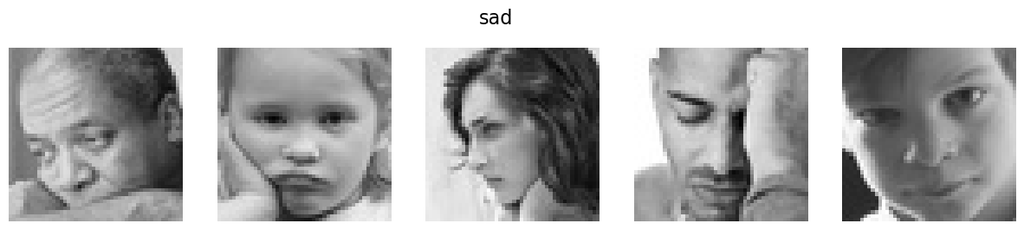

[figure not shown]

```python
def show_random_images(data_path, num_images=5):
    """
    Show random images from each class in the dataset.

    Parameters:
    data_path (str): The path to the dataset.
    num_images (int): Number of images to show from each class.
    """
    classes = os.listdir(data_path)
    for class_name in classes:
        class_path = os.path.join(data_path, class_name)
        if os.path.isdir(class_path):
            image_files = os.listdir(class_path)
            random_images = random.sample(image_files, num_images)

            plt.figure(figsize=(15, 3))
            plt.suptitle(class_name, fontsize=16)
            for i, image_file in enumerate(random_images):
                plt.subplot(1, num_images, i + 1)
                img = cv2.imread(os.path.join(class_path, image_file))
                img = cv2.cvtColor(img, cv2.COLOR_BGR2RGB)
                plt.imshow(img)
                plt.axis('off')
            plt.show()

# Show random images from each class in the training dataset
show_random_images(train_data)
```

### Check that image size and shape are consistent

```python
def check_image_sizes(data_path):
    """
    Check the sizes of images in the dataset and print unique sizes.

    Parameters:
    data_path (str): The path to the dataset.
    """
    sizes = set()
    for root, dirs, files in os.walk(data_path):
        for file in files:
            if file.lower().endswith(('.png', '.jpg', '.jpeg')):
                img_path = os.path.join(root, file)
                img = cv2.imread(img_path)
                sizes.add(img.shape)

    print("Unique image sizes:", sizes)

# Check image sizes in the training dataset
check_image_sizes(train_data)
```

```
Unique image sizes: {(48, 48, 3)}
```

### Checking the distribution of pixels

To see if we need any further normalization or scaling

**let's plot pixel value distribution to check consistency**

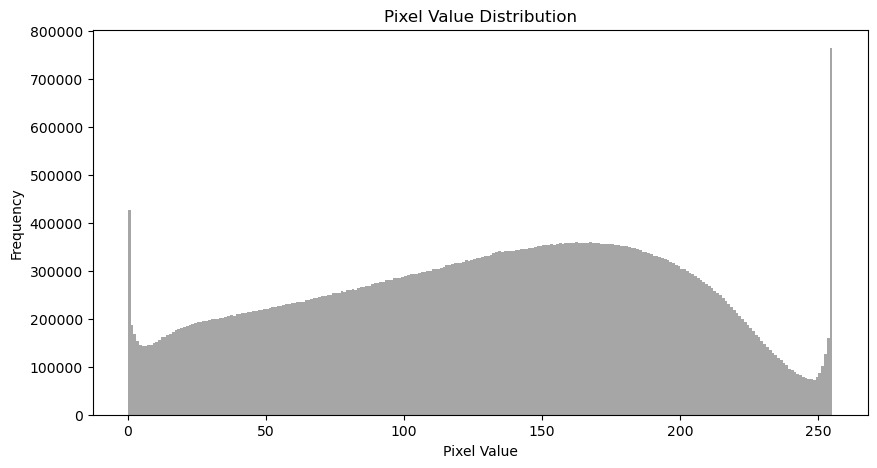

```python
def plot_pixel_distribution(data_path):
    """
    Plot the distribution of pixel values in the dataset.

    Parameters:
    data_path (str): The path to the dataset.
    """
    pixel_values = []
    for root, dirs, files in os.walk(data_path):
        for file in files:
            if file.lower().endswith(('.png', '.jpg', '.jpeg')):
                img_path = os.path.join(root, file)
                img = cv2.imread(img_path, cv2.IMREAD_GRAYSCALE)  # Assuming grayscale images
                pixel_values.extend(img.ravel())

    plt.figure(figsize=(10, 5))
    plt.hist(pixel_values, bins=255, color='gray', alpha=0.7)
    plt.title('Pixel Value Distribution')
    plt.xlabel('Pixel Value')
    plt.ylabel('Frequency')
    plt.show()

# Plot pixel value distribution for the training dataset
plot_pixel_distribution(train_data)
```

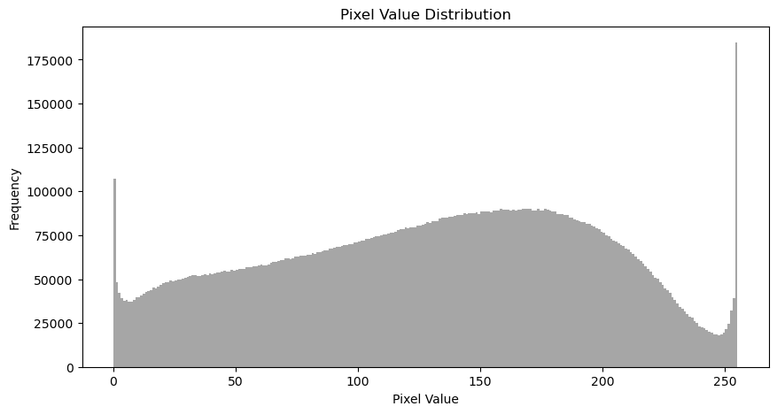

```python
plot_pixel_distribution(test_data)
```

# EDA Conclusion

Looking at the pixel distribution we notice there are spikes at the ends. This is due to the fact there are a lot of black and white photos as seen in the random sample. All the images are consistent in terms of size and color gradient. There is a class imbalance that we will try to handle before modeling using a couple different techniques. I want to use a couple different techniques in order to see if one is "better" than another or produces models that are supererior.

# DATA PREPROCESSING

*We will balance weights and compare the balanced weight models to the models with unbalanced weights*

We chose this method because it seems as if it is a direct answer to the Class Distribution Disparity.

we have already done some basic data augmentation close to the beginning of this notebook with the **ImageDataGenerator** code.

## 1 - Class Weight Calculation

```python
labels = np.unique(train_generator.classes)
weights = compute_class_weight('balanced', classes=labels, y=train_generator.classes)
class_weights = dict(zip(labels, weights))

print("Class weights:", class_weights)
```

```
Class weights: {0: 1.0266404434114071, 1: 9.401555464592715, 2: 1.0009587727708533, 3: 0.5684585684585685, 4: 0.826068191627104, 5: 0.8491570541259982, 6: 1.2933160650937552}
```

Class weights: {'angry': 1.0266404434114071, 'disgust': 9.401555464592715, 'fear': 1.0009587727708533, 'happy': 0.5684585684585685, 'neutral': 0.826068191627104, 'sad': 0.8491570541259982, 'surprise': 1.2933160650937552}

# 1 - Training

### CNN

For each model type we will create two models with and without the weights balanced.

```python
from tensorflow.keras.models import Sequential
from tensorflow.keras.layers import Conv2D, MaxPooling2D, Flatten, Dense, Dropout

def create_cnn_model(input_shape):
    model = Sequential()
    model.add(Conv2D(32, (3, 3), activation='relu', input_shape=input_shape))
    model.add(MaxPooling2D((2, 2)))
    model.add(Conv2D(64, (3, 3), activation='relu'))
    model.add(MaxPooling2D((2, 2)))
    model.add(Flatten())
    model.add(Dense(64, activation='relu'))
    model.add(Dense(7, activation='softmax'))
    return model

# Without class weights
model_without_weights = create_cnn_model((48, 48, 3))
model_without_weights.compile(optimizer='adam', loss='categorical_crossentropy', metrics=['accuracy'])
history_without_weights = model_without_weights.fit(train_generator, epochs=10, validation_data=validation_generator)

# With class weights
model_with_weights = create_cnn_model((48, 48, 3))
model_with_weights.compile(optimizer='adam', loss='categorical_crossentropy', metrics=['accuracy'])
history_with_weights = model_with_weights.fit(train_generator, epochs=10, validation_data=validation_generator, class_weight=class_weights)
```

## Support Vector Machine

```python
import numpy as np
from sklearn import svm
from sklearn.metrics import classification_report
from sklearn.model_selection import train_test_split
from sklearn.preprocessing import LabelEncoder

# Preprocess the data
X_train, y_train = next(train_generator)
X_val, y_val = next(validation_generator)

# Flatten the data
X_train_flat = X_train.reshape(X_train.shape[0], -1)
X_val_flat = X_val.reshape(X_val.shape[0], -1)

# Convert one-hot encoded labels to single numbers
y_train_single = np.argmax(y_train, axis=1)
y_val_single = np.argmax(y_val, axis=1)

# Initialize SVM without class weights
svm_clf_without_weights = svm.SVC(kernel='linear')

# Train SVM without class weights
svm_clf_without_weights.fit(X_train_flat, y_train_single)

# Predictions and Evaluation for SVM without class weights
y_pred_svm_without_weights = svm_clf_without_weights.predict(X_val_flat)
print("Classification Report for SVM without Class Weights:")
print(classification_report(y_val_single, y_pred_svm_without_weights))

# Initialize SVM with class weights
svm_clf_with_weights = svm.SVC(class_weight=class_weights, kernel='linear')

# Train SVM with class weights
svm_clf_with_weights.fit(X_train_flat, y_train_single)

# Predictions and Evaluation for SVM with class weights
y_pred_svm_with_weights = svm_clf_with_weights.predict(X_val_flat)
print("Classification Report for SVM with Class Weights:")
print(classification_report(y_val_single, y_pred_svm_with_weights))
```

```
Classification Report for SVM without Class Weights:
              precision    recall  f1-score   support

           0       0.17      0.33      0.22         3
           1       1.00      1.00      1.00         1
           2       0.23      0.43      0.30         7
           3       0.33      0.33      0.33         3
           4       0.12      0.17      0.14         6
           5       0.00      0.00      0.00         8
           6       0.00      0.00      0.00         4

    accuracy                           0.22        32
   macro avg       0.27      0.32      0.29        32
weighted avg       0.15      0.22      0.18        32

Classification Report for SVM with Class Weights:
              precision    recall  f1-score   support

           0       0.17      0.33      0.22         3
           1       1.00      1.00      1.00         1
           2       0.23      0.43      0.30         7
           3       0.33      0.33      0.33         3
           4       0.12      0.17      0.14         6
           5       0.00      0.00      0.00         8
           6       0.00      0.00      0.00         4

    accuracy                           0.22        32
   macro avg       0.27      0.32      0.29        32
weighted avg       0.15      0.22      0.18        32
```

## Artificial Neural Network

```python
def create_ann_model():
    model = Sequential()
    model.add(Flatten(input_shape=(48, 48, 3)))
    model.add(Dense(128, activation='relu'))
    model.add(Dense(7, activation='softmax'))
    return model

# Without class weights
ann_model_without_weights = create_ann_model()
ann_model_without_weights.compile(optimizer='adam', loss='categorical_crossentropy', metrics=['accuracy'])
history_without_weights = ann_model_without_weights.fit(train_generator, epochs=10, validation_data=validation_generator)

# With class weights
ann_model_with_weights = create_ann_model()
ann_model_with_weights.compile(optimizer='adam', loss='categorical_crossentropy', metrics=['accuracy'])
history_with_weights = ann_model_with_weights.fit(train_generator, epochs=10, validation_data=validation_generator, class_weight=class_weights)
```

## Pre-trained Keras Model "VGG16"

```python
def create_vgg16_model(input_shape):
    base_model = VGG16(weights='imagenet', include_top=False, input_shape=input_shape)
    x = Flatten()(base_model.output)
    x = Dense(64, activation='relu')(x)
    predictions = Dense(7, activation='softmax')(x)
    model = Model(inputs=base_model.input, outputs=predictions)
    return model

# Without class weights
vgg_model_without_weights = create_vgg16_model((48, 48, 3))
vgg_model_without_weights.compile(optimizer='adam', loss='categorical_crossentropy', metrics=['accuracy'])
history_vgg_without_weights = vgg_model_without_weights.fit(train_generator, epochs=10, validation_data=validation_generator)

# With class weights
vgg_model_with_weights = create_vgg16_model((48, 48, 3))
vgg_model_with_weights.compile(optimizer='adam', loss='categorical_crossentropy', metrics=['accuracy'])
history_vgg_with_weights = vgg_model_with_weights.fit(train_generator, epochs=10, validation_data=validation_generator, class_weight=class_weights)
```

```
Downloading data from https://storage.googleapis.com/tensorflow/keras-applications/vgg16/vgg16_weights_tf_dim_ordering_tf_kernels_notop.h5
```

## Save Models

```python
model_without_weights.save("cnn_without.h5")
model_with_weights.save("cnn_with.h5")
ann_model_with_weights.save("ann_with.h5")
ann_model_without_weights.save("ann_without.h5")
vgg_model_without_weights.save("vgg_without.h5")
vgg_model_with_weights.save("vgg_with.h5")
```

```python
# Specifying the save path
save_path = "C:/Users/Garrett Bainwol/Desktop/DTSA_5511_Final_Project/"

# Saving the models to the specified path
model_without_weights.save(save_path + "cnn_without.h5")
model_with_weights.save(save_path + "cnn_with.h5")
ann_model_with_weights.save(save_path + "ann_with.h5")
ann_model_without_weights.save(save_path + "ann_without.h5")
vgg_model_without_weights.save(save_path + "vgg_without.h5")
vgg_model_with_weights.save(save_path + "vgg_with.h5")
```

# 2 - Evaluation

```
CNN Model without weights Test Accuracy: 0.5203399062156677
CNN Model with weights Test Accuracy: 0.4937308430671692
```

[figure not shown]

[figure not shown]

```python
def plot_history(history, title=''):
    plt.figure(figsize=(12, 4))

    # Accuracy
    plt.subplot(1, 2, 1)
    plt.plot(history.history['accuracy'])
    plt.plot(history.history['val_accuracy'])
    plt.title(f'Accuracy {title}')
    plt.ylabel('Accuracy')
    plt.xlabel('Epoch')
    plt.legend(['Train', 'Val'], loc='upper left')

    # Loss
    plt.subplot(1, 2, 2)
    plt.plot(history.history['loss'])
    plt.plot(history.history['val_loss'])
    plt.title(f'Loss {title}')
    plt.ylabel('Loss')
    plt.xlabel('Epoch')
    plt.legend(['Train', 'Val'], loc='upper left')

    plt.tight_layout()
    plt.show()

# Evaluating and plotting for the CNN model
loss, acc = model_without_weights.evaluate(test_generator)
print(f"CNN Model without weights Test Accuracy: {acc}")

loss, acc = model_with_weights.evaluate(test_generator)
print(f"CNN Model with weights Test Accuracy: {acc}")

plot_history(history_without_weights, 'Model Without Weights')
plot_history(history_with_weights, 'Model With Weights')
```

```
ANN Model without weights Test Accuracy: 0.342713862657547
ANN Model with weights Test Accuracy: 0.14279744029045105
```

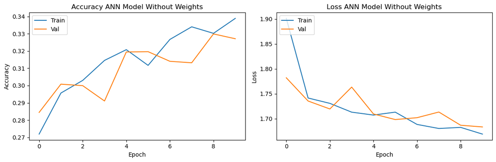

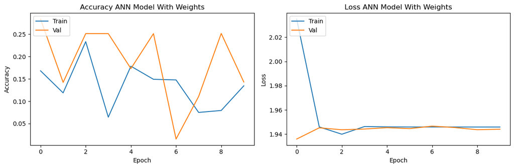

```
VGG16 Model without weights Test Accuracy: 0.24714405834674835
VGG16 Model with weights Test Accuracy: 0.17177486419677734
```

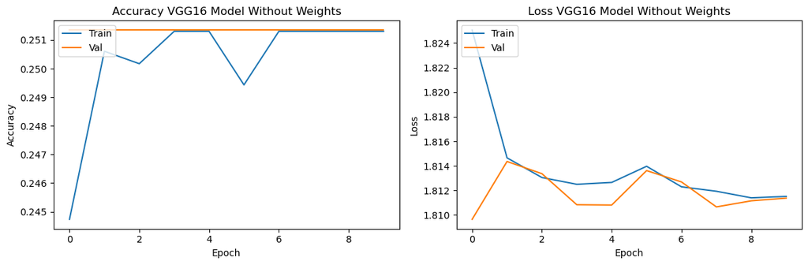

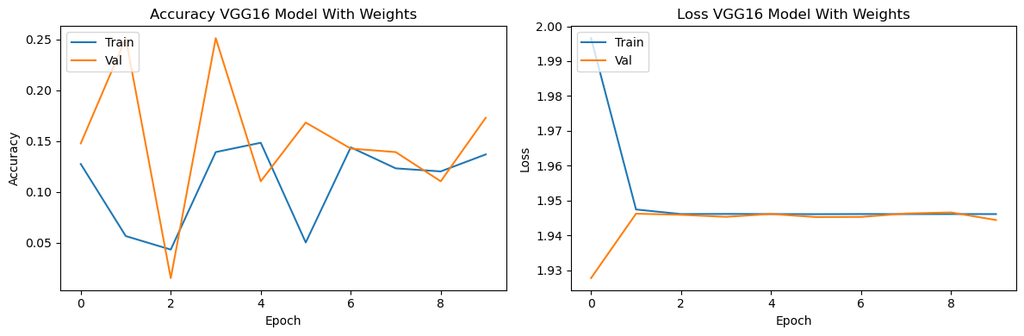

```python
# Evaluation and plotting for the ANN model
loss, acc = ann_model_without_weights.evaluate(test_generator)
print(f"ANN Model without weights Test Accuracy: {acc}")

loss, acc = ann_model_with_weights.evaluate(test_generator)
print(f"ANN Model with weights Test Accuracy: {acc}")

plot_history(history_without_weights, 'ANN Model Without Weights')
plot_history(history_with_weights, 'ANN Model With Weights')

# Evaluation and plotting for the VGG16 model
loss, acc = vgg_model_without_weights.evaluate(test_generator)
print(f"VGG16 Model without weights Test Accuracy: {acc}")

loss, acc = vgg_model_with_weights.evaluate(test_generator)
print(f"VGG16 Model with weights Test Accuracy: {acc}")

plot_history(history_vgg_without_weights, 'VGG16 Model Without Weights')
plot_history(history_vgg_with_weights, 'VGG16 Model With Weights')
```

```python
# SVM without class weights
y_pred_svm_without_weights = svm_clf_without_weights.predict(X_val_flat)
print("Classification Report for SVM without Class Weights:")
print(classification_report(y_val_single, y_pred_svm_without_weights))

# SVM with class weights
y_pred_svm_with_weights = svm_clf_with_weights.predict(X_val_flat)
print("Classification Report for SVM with Class Weights:")
print(classification_report(y_val_single, y_pred_svm_with_weights))
```

```
Classification Report for SVM without Class Weights:
              precision    recall  f1-score   support

           0       0.17      0.33      0.22         3
           1       1.00      1.00      1.00         1
           2       0.23      0.43      0.30         7
           3       0.33      0.33      0.33         3
           4       0.12      0.17      0.14         6
           5       0.00      0.00      0.00         8
           6       0.00      0.00      0.00         4

    accuracy                           0.22        32
   macro avg       0.27      0.32      0.29        32
weighted avg       0.15      0.22      0.18        32

Classification Report for SVM with Class Weights:
              precision    recall  f1-score   support

           0       0.17      0.33      0.22         3
           1       1.00      1.00      1.00         1
           2       0.23      0.43      0.30         7
           3       0.33      0.33      0.33         3
           4       0.12      0.17      0.14         6
           5       0.00      0.00      0.00         8
           6       0.00      0.00      0.00         4

    accuracy                           0.22        32
   macro avg       0.27      0.32      0.29        32
weighted avg       0.15      0.22      0.18        32
```

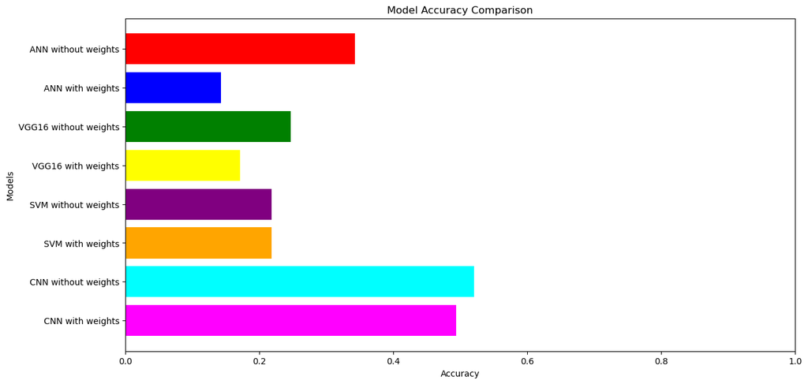

```python
# For ANN models
acc_ann_without_weights = ann_model_without_weights.evaluate(test_generator, verbose=0)[1]
acc_ann_with_weights = ann_model_with_weights.evaluate(test_generator, verbose=0)[1]

# For VGG16 models
acc_vgg_without_weights = vgg_model_without_weights.evaluate(test_generator, verbose=0)[1]
acc_vgg_with_weights = vgg_model_with_weights.evaluate(test_generator, verbose=0)[1]

# For SVM models (using the classification report)
report_svm_without_weights = classification_report(y_val_single, y_pred_svm_without_weights, output_dict=True)
acc_svm_without_weights = report_svm_without_weights['accuracy']

report_svm_with_weights = classification_report(y_val_single, y_pred_svm_with_weights, output_dict=True)
acc_svm_with_weights = report_svm_with_weights['accuracy']

# For CNN models
acc_cnn_without_weights = model_without_weights.evaluate(test_generator, verbose=0)[1]
acc_cnn_with_weights = model_with_weights.evaluate(test_generator, verbose=0)[1]


# List of model names
models = ['ANN without weights', 'ANN with weights',
          'VGG16 without weights', 'VGG16 with weights',
          'SVM without weights', 'SVM with weights',
          'CNN without weights', 'CNN with weights']

# Updated list of accuracies
accuracies = [acc_ann_without_weights, acc_ann_with_weights,
              acc_vgg_without_weights, acc_vgg_with_weights,
              acc_svm_without_weights, acc_svm_with_weights,
              acc_cnn_without_weights, acc_cnn_with_weights]

# Create updated bar chart
plt.figure(figsize=(14, 7))
plt.barh(models, accuracies, color=['red', 'blue', 'green', 'yellow', 'purple', 'orange', 'cyan', 'magenta'])
plt.xlabel('Accuracy')
plt.ylabel('Models')
plt.title('Model Accuracy Comparison')
plt.xlim(0, 1)  # assuming accuracy is in decimal form
plt.gca().invert_yaxis()  # for top-down display
plt.show()
```

```python
def plot_confusion_matrix(model, generator):
    # Getting predictions
    y_pred = model.predict(generator)
    y_pred_classes = np.argmax(y_pred, axis=1)
    y_true = generator.classes

    # Confusion matrix
    cm = confusion_matrix(y_true, y_pred_classes, labels=labels)

    # Plotting
    plt.figure(figsize=(10, 7))
    sns.heatmap(cm, annot=True, fmt='d', cmap='Blues')
    plt.xlabel('Predicted')
    plt.ylabel('True')
    plt.show()
```

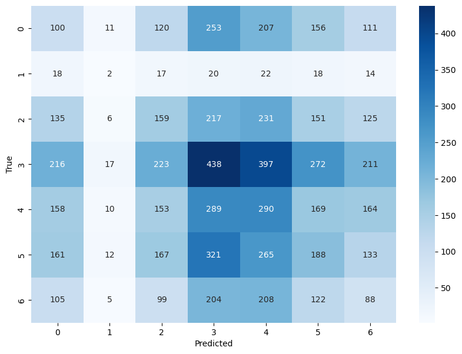

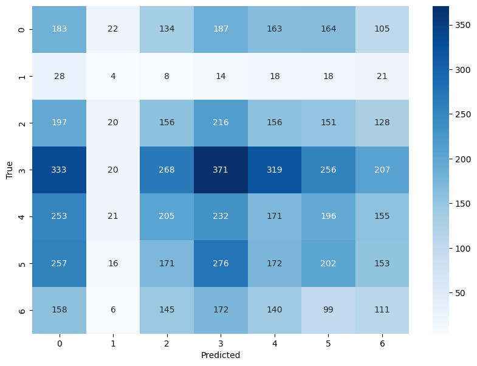

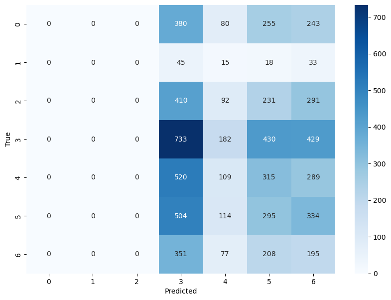

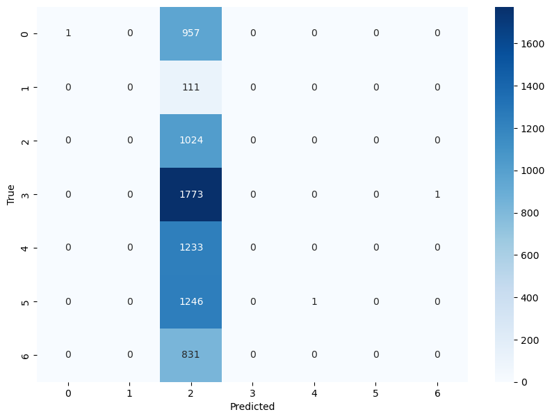

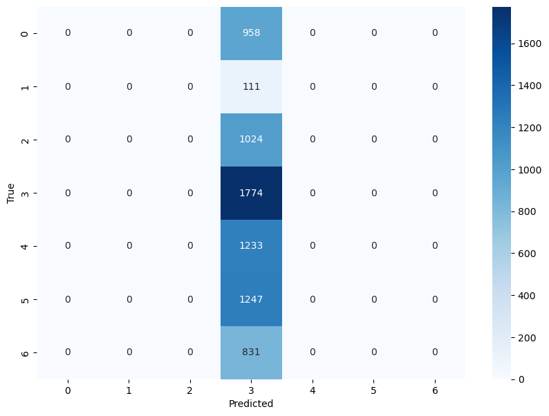

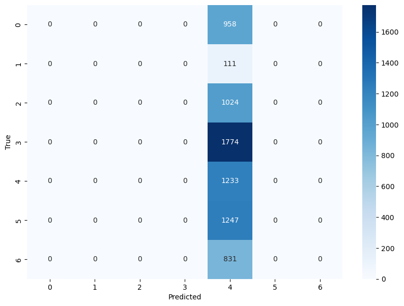

```python
# Plot confusion matrix for CNN Models
plot_confusion_matrix(model_without_weights, test_generator)
plot_confusion_matrix(model_with_weights, test_generator)

# Plot confusion matrix for ANN models
plot_confusion_matrix(ann_model_without_weights, test_generator)
plot_confusion_matrix(ann_model_with_weights, test_generator)

# Plot confusion matrix for VGG16 models
plot_confusion_matrix(vgg_model_without_weights, test_generator)
plot_confusion_matrix(vgg_model_with_weights, test_generator)
```

# Project Conclusion

## Model Accuracy and Loss Comparison

### Overview:

The bar chart displays a comparison of the accuracy of various machine learning models with and without weights.

### Detailed Breakdown:

#### 1. ANN Model:

**Without Weights:**

**With Weights:**

#### 2. VGG16 Model:

**Without Weights:**

### Recommendations:

- For highest accuracy, consider using or further tuning the CNN model.
- Investigate the data and model architectures further to determine the reasons behind the performance discrepancies and the impact of weights.